# Cabbages

Alma Andreasian

9/7/21

# Introduction

The cabbages data from the MASS package is loaded into a dataframe called veggy. Complete this report by answering the following two questions

### Is there a difference in average VitC between c39 and c52 cultivation methods?

$H_0$ There is no difference in the Vitamin C content of cabagges cultivated with methods 39 and 52.

$H_A$ There is a diffference in the vitamin C content based on cultivation method.

# Methods

VitC is a numerical variable. Cult is categorical variable, So the helper file we need is the numerical cat.

# Results

## Descriptive Results

### Graphical Descriptive Results

```r
basicCN <- ggplot(veggy,aes(x=Cult,y=VitC))
```

## Now Add in a Box plot

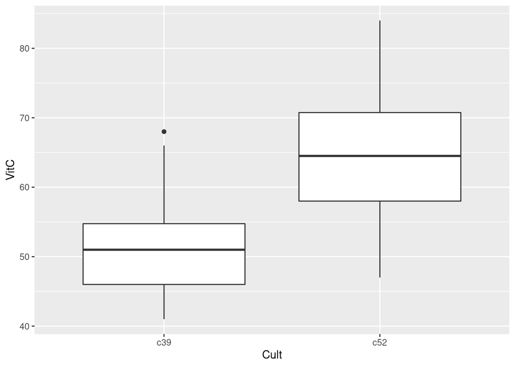

```r
basicCN + geom_boxplot()
```

## get fancy

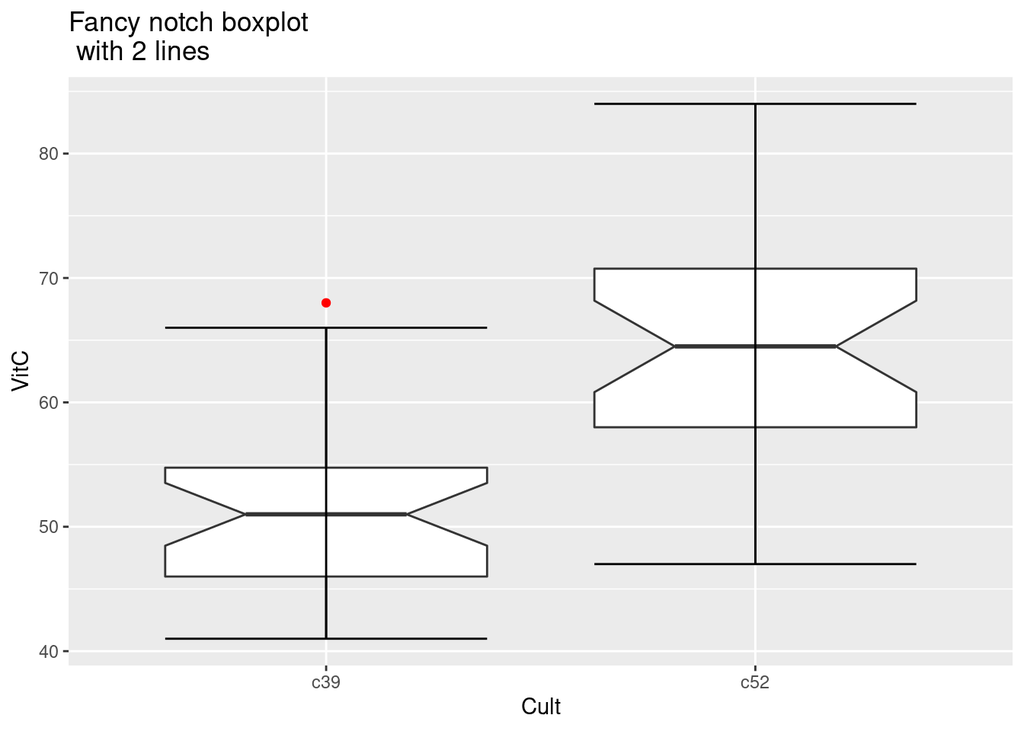

```r
basicCN + geom_boxplot(notch=TRUE,outlier.color = "red") + stat_boxplot(geom ='errorbar') + labs(title="Fancy notch boxplot \n with 2 lines")
```

Cultivation c39 has vitamin C content of about 52 and cultivation C52 has a vitamin c content of about 64

### Numerical Descriptive Results

```r
favstats(VitC~Cult,data=veggy)
```

```
##   Cult min Q1 median    Q3 max mean       sd  n missing
## 1  c39  41 46   51.0 54.75  68 51.5 7.123298 30       0
## 2  c52  47 58   64.5 70.75  84 64.4 8.455156 30       0
```

## Inferential Results

```r
t.test(VitC~Cult,data=veggy)
```

```
##
##  Welch Two Sample t-test
##
## data:  VitC by Cult
## t = -6.3909, df = 56.376, p-value = 3.405e-08
## alternative hypothesis: true difference in means between group c39 and group c52 is not equal to 0
## 95 percent confidence interval:
##  -16.94296  -8.85704
## sample estimates:
## mean in group c39 mean in group c52
##              51.5              64.4
```

# Discussion and Conclusion

I reject the null hypothesis. Cabbages cultivated with c52 have more vitamin c than cabbages cultivated with c39.